# Reflections on NY Phil – The NY Phil as a lens on changes in US society

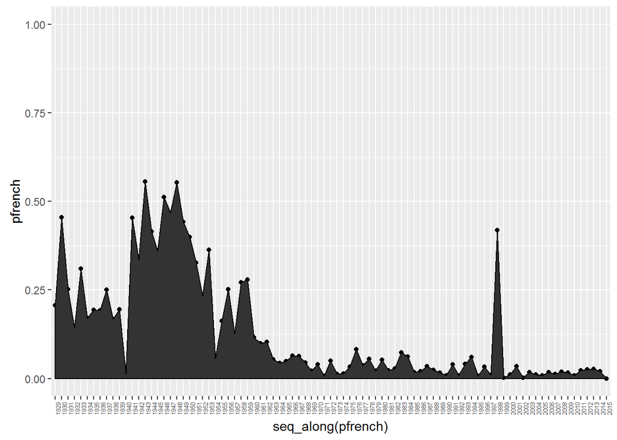

```r
qplot(seq_along(pfrench),pfrench)+geom_line()+ylim(0,1)+geom_area(colour="black")+ scale_x_discrete(labels =(1929:2015))+ theme(axis.text.x = element_text(angle = 90,size=5, hjust = 1))
```

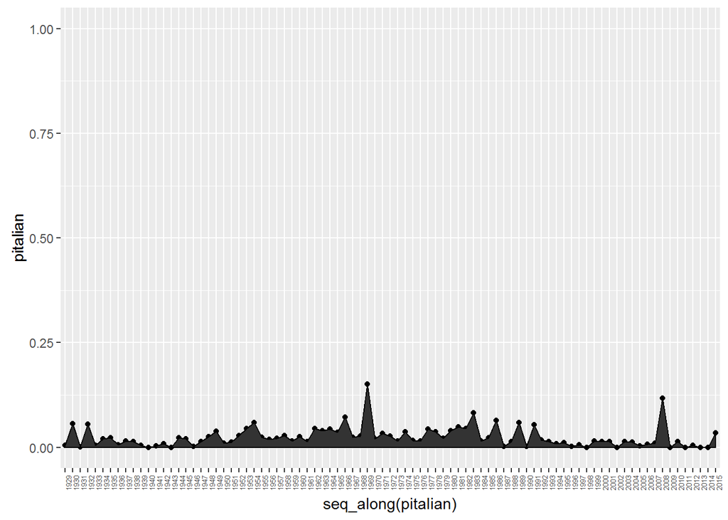

```r
qplot(seq_along(pitalian),pitalian)+geom_line()+ylim(0,1)+geom_area(colour="black")+ scale_x_discrete(labels =(1929:2015))+ theme(axis.text.x = element_text(angle = 90,size=5, hjust = 1))
```

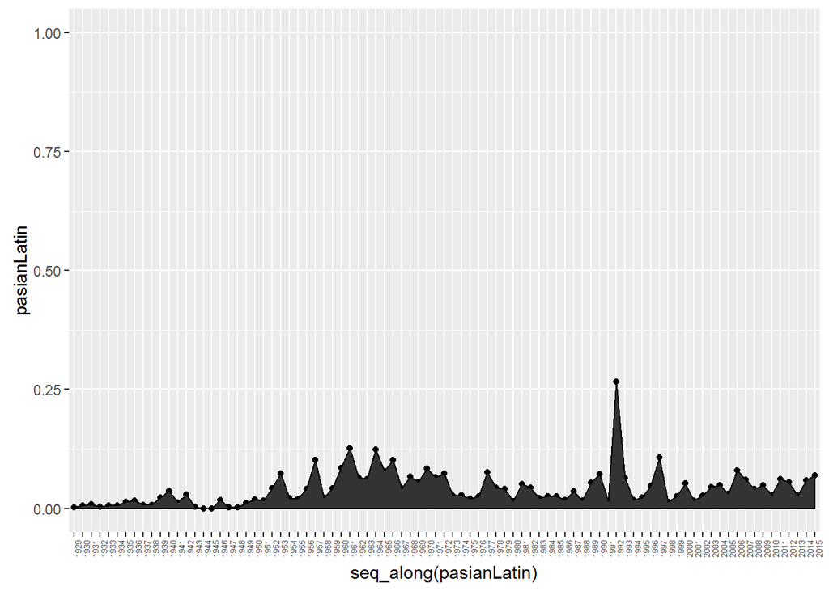

```r
qplot(seq_along(pasianLatin),pasianLatin)+geom_line()+ylim(0,1)+geom_area(colour="black")+ scale_x_discrete(labels =(1929:2015))+ theme(axis.text.x = element_text(angle = 90,size=5, hjust = 1))
```

ask: 3. underreresented countries on wiki, esp asian and latin and soviet and the art and music correspondenceness in terms of countries (asian, and latin american) 2. woman composer matching. 1. stacked barchart. is it needed?

4. gdp graph (strange range)
5. (jewish exampple. x axis gone)

to do: 8. try dana’s matching alg 9. try new women composer matching 10. asian, and latin

gershwin and kate global impressionist thingie